# TLimmuno2 can learn important features that determine immunogenicity

2. split mutated peptides into 15mer subsequence:

```python
#python
#PBS
import pandas as pd
import os
import re
file_path = "/public/slst/home/wanggsh/TCGA-process/Res"
tumor_type = os.listdir(file_path)
colnames = ["chr","start","end","ref","alt","pos_alter","cdna","transcript","pos","indel","ext_seqs_wt","ext_seqs_mt","tumor_sample_barcode"]
def mer15(Pep):
    P = []
    Length = 15
    for i in range(len(Pep) - Length +1):
        pep = Pep[i:i+Length]
        P.append(pep)
    return P
for i in tumor_type:
    DF = pd.DataFrame()
    pep_file_path = "/public/slst/home/wanggsh/TCGA-process/Res/{0}/Pep".format(i)
    pep_file = os.listdir(pep_file_path)
    for x in pep_file:
        tumor_barcode = re.split("\.",x)[0]
        pep = pd.read_csv("{0}/{1}".format(pep_file_path,x),names = colnames)
        pep = pep[["chr","start","end","ref","alt","ext_seqs_mt","tumor_sample_barcode"]]
        pep = pep.drop_duplicates()
        pep["length"] = pep["ext_seqs_mt"].map(len)
        pep = pep.query("length >=15")
        Pep15 = []
        Pep_num = []
        Chrom = []
        Start = []
        End = []
        Refer = []
        Alt = []
        pep = pep.reset_index(drop=True)
        for y in range(len(pep)):
            res = mer15(pep["ext_seqs_mt"][y])
            pep_num = ["Pep{0}".format(y+1)] *len(res)
            chrom = [pep["chr"][y]] *len(res)
            start = [pep["start"][y]] *len(res)
            end = [pep["end"][y]] *len(res)
            refer = [pep["ref"][y]] *len(res)
            alt = [pep["alt"][y]] *len(res)
            Pep15.extend(res)
            Pep_num.extend(pep_num)
            Chrom.extend(chrom)
            Start.extend(start)
            End.extend(end)
            Refer.extend(refer)
            Alt.extend(alt)
        df = pd.DataFrame({"chr":Chrom,"start":Start,"end":End,"ref":Refer,"alt":Alt,"ext_seqs_mt":Pep15,"Pep_num":Pep_num})
        df["tumor_sample_barcode"] = tumor_barcode
        DF = pd.concat([DF,df])
    print("{0} Finish".format(i))
    DF = DF.drop_duplicates()
    DF.to_csv("/public/slst/home/wanggsh/TCGA-process/mut_pep2/{0}_pep.csv".format(i))
```

3. predicte peptide score by using TLimmuno2. HLA typing data was downloaded from [Benchmarking HLA genotyping and clarifying HLA impact on survival in tumor immunotherapy](https://doi.org/10.1002/1878-0261.12895) study and transformed to the format required by the neoantigen prediction tools. we predicted HLA-DR immunogenicity score of mutated peptides’ subsequence.

```python
#python
#PBS
import pandas as pd
import numpy as np
import tensorflow as tf
import sys
sys.path.append("/public/slst/home/wanggsh/Project/MHCII/utils")
from Blosum62 import blosum62
import os
import re
os.environ["CUDA_VISIBLE_DEVICES"]="-1"
#load_model

#strategy = tf.distribute.MirroredStrategy() #use mutiple GPU
BA_model = tf.keras.models.load_model("/public/slst/home/wanggsh/Project/Saved_model/new_BA_model/model1")
BAmodel = tf.keras.models.Model(inputs = BA_model.input,outputs = BA_model.layers[-2].output)
IMM = tf.keras.models.load_model("/public/slst/home/wanggsh/Project/Saved_model/MHCII_immuno/model")
#mutant pep file

mut_pep_file_path ="/public/slst/home/wanggsh/TCGA-process/mut_pep2"

MHC_II = pd.read_csv("/public/slst/home/wanggsh/TCGA-process/TCGA-MHCII-allele.csv")
pseudo_seq = pd.read_table("/public/slst/home/wanggsh/Data/MHCII/pseudosequence.2016.all.X.dat",names=["hla","sequence"])
i = sys.argv[1]
tumor = re.sub("_pep.csv","",i)
print("{0} Start".format(tumor))
Data = pd.read_csv("{0}/{1}".format(mut_pep_file_path,i))
MHC_II_smal = MHC_II[MHC_II["project_id"] == tumor]
Data["Sample_Barcode"] = Data["tumor_sample_barcode"].map(lambda x : x[0:12])
Data = pd.merge(Data,MHC_II_smal[["Sample_Barcode","hla"]])
Data = pd.merge(Data,pseudo_seq)
Data["pep_blosum"] = Data["ext_seqs_mt"].apply(blosum62,args=(21,))
Data["MHC_blosum"] = Data["sequence"].apply(blosum62,args=(34,))
peptide = np.empty((len(Data),21,21))
for i in range(len(Data)):
    peptide[i] = Data["pep_blosum"][i].reshape((21,21))

MHC = np.empty((len(Data),34,21))
for i in range(len(Data)):
    MHC[i] = Data["MHC_blosum"][i].reshape((34,21))

BA = BAmodel.predict([peptide,MHC])
IMM_result = IMM.predict([peptide,MHC,BA])
Data["prediction"] = IMM_result
Data.pop("Unnamed: 0")
Data.pop("sequence")
Data.pop("pep_blosum")
Data.pop("MHC_blosum")
Data.to_csv("/public/slst/home/wanggsh/TCGA-process/Prediction/IMM2/{0}.csv".format(tumor))
print("{0} Finish".format(tumor))
```

4.Background peptide predict

```python
#PBS
#python
import pandas as pd
import sys
import numpy as np
sys.path.append("/public/slst/home/wanggsh/Project/MHCII/utils")
from Blosum62 import blosum62
import os
#os.environ["CUDA_VISIBLE_DEVICES"]="-1"
import tensorflow as tf
BA_model = tf.keras.models.load_model("/public/slst/home/wanggsh/Project/Saved_model/new_BA_model/model1")
BAmodel = tf.keras.models.Model(inputs = BA_model.input,outputs = BA_model.layers[-2].output)
IMM = tf.keras.models.load_model("/public/slst/home/wanggsh/Project/Saved_model/MHCII_immuno/model")
TCGA_allele = pd.read_csv("/public/slst/home/wanggsh/TCGA-process/TCGA-MHCII-allele.csv")
pseudo_seq2 = pd.read_feather("/public/slst/home/wanggsh/Data/pseudo_blosum62.feather")
IMM_bg_pep = pd.read_csv("/public/slst/home/wanggsh/Data/MHCII_immuno/IMM_bg_pep.csv")
IMM_bg_pep["pep_blosum"] = IMM_bg_pep["pep"].apply(blosum62,args=(21,))
inteset = np.intersect1d(TCGA_allele["hla"].values,pseudo_seq2["MHC"].values)
#np.setdiff1d(TCGA_allele["hla"].values,pseudo_seq2["MHC"].values)
for i in inteset:
    DF = pd.DataFrame()
    IMM_bg_pep["MHC"] = i
    x = pd.merge(IMM_bg_pep,pseudo_seq2[["MHC","MHC_blosum"]])
    DF = pd.concat([DF,x])
    peptide = np.empty((len(DF),21,21))
    for z in range(len(DF)):
        peptide[z] = DF["pep_blosum"][z].reshape((21,21))
    MHC = np.empty((len(DF),34,21))
    for z in range(len(DF)):
        MHC[z] = x["MHC_blosum"][z].reshape((34,21))
    BA = BAmodel.predict([peptide,MHC])
    IMM_result = IMM.predict([peptide,MHC,BA])
    DF["Prediction"] = IMM_result
    DF = DF.drop(["Unnamed: 0","pep_blosum","MHC_blosum"],axis=1)
    DF.to_csv("/public/slst/home/wanggsh/TCGA-process/back_ground_pep/{0}.csv".format(i))
```

5.Ranking: use background peptides to do rank

```python
#PBS_batch
#python
import pandas as pd
import numpy as np
import tensorflow as tf
import sys
sys.path.append("/public/slst/home/wanggsh/Project/MHCII/utils")
from Blosum62 import blosum62
import os
import re
os.environ["CUDA_VISIBLE_DEVICES"]="-1"

IMM_resul_path = "/public/slst/home/wanggsh/TCGA-process/Prediction/IMM"
background_path = "/public/slst/home/wanggsh/TCGA-process/back_ground_pep"
file = os.listdir(IMM_resul_path)
arg = sys.argv[1]
res = pd.read_csv("{}/{}".format(IMM_resul_path,arg))
DF = pd.DataFrame()
for y in res["hla"].unique():
    res_all = res[res["hla"]==y]
    back_ground = pd.read_csv("{}/{}.csv".format(background_path,y))
    back_ground = back_ground["Prediction"].values.tolist()
    Rank = []
    for I in res_all["prediction"].values:
        back_ground.append(I)
        rank = 1-(sorted(back_ground).index(back_ground[-1])+1)/90001
        Rank.append(rank)
        back_ground.pop()
    res_all["Rank"] = Rank
    DF = pd.concat([DF,res_all])
DF.to_csv("/public/slst/home/wanggsh/TCGA-process/Prediction/IMM_rank/{0}_rank.csv".format(arg))
```

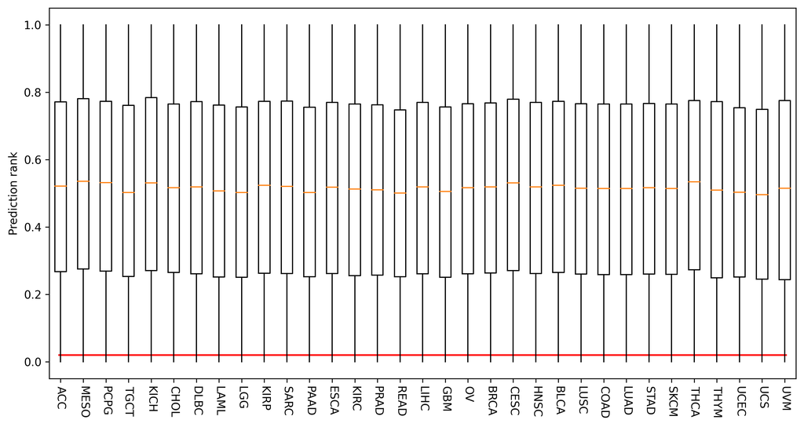

TCGA-Rank

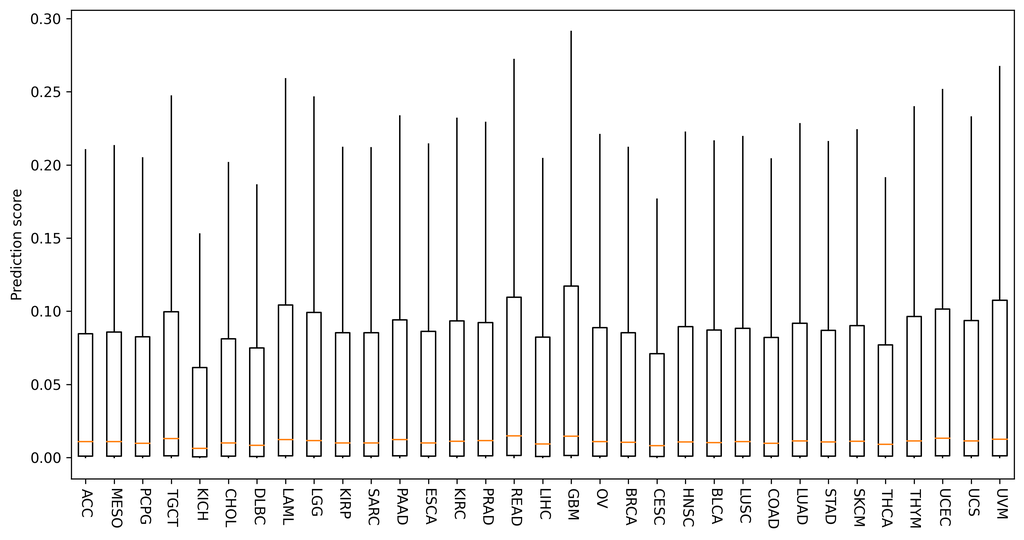

TCGA-prediction-score-withoutdiscretevalue

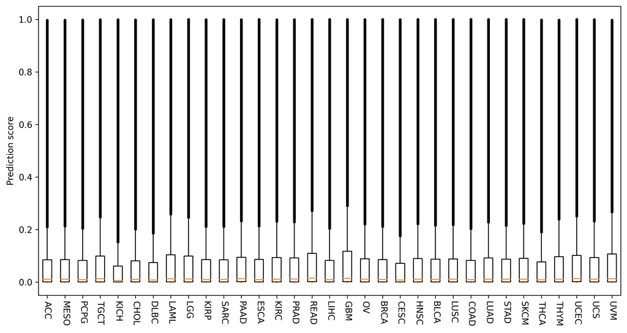

TCGA-prediction-score

```python
#python
#PBS
import pandas as pd
import matplotlib.pyplot as plt
import os
import re
import numpy as np

file_path = "/public/slst/home/wanggsh/TCGA-process/Prediction/IMM_rank2"
file = os.listdir(file_path)

Barcode = []
Rank = []
for i in file:
    Data = pd.read_csv("{}/{}".format(file_path,i))
    tumor = re.split(".csv_rank.csv",i)[0]
    Barcode.append(tumor)
    Rank.append(Data["Rank"])
Rank = np.array(Rank)
np.save("/public/slst/home/wanggsh/TCGA-process/Prediction/TCGA_rank.npy",Rank)
barcode = []
for i in Barcode:
    x = re.split("TCGA_",i)[1]
    barcode.append(x)
fig,axs = plt.subplots(figsize = (12,6))
plt.boxplot(Rank,labels=barcode,showcaps=False)
plt.xticks(rotation = 270)
plt.hlines(0.02,colors="red",xmin=0.9,xmax=33.1)
plt.ylabel("Prediction rank")
plt.savefig("/public/slst/home/wanggsh/TCGA-process/TCGA-rank.png",dpi = 300,bbox_inches='tight',transparent=True)

Barcode = []
Prediction = []
for i in file:
    Data = pd.read_csv("{}/{}".format(file_path,i))
    tumor = re.split(".csv_rank.csv",i)[0]
    Barcode.append(tumor)
    Prediction.append(Data["prediction"])
Prediction = np.array(Prediction)
np.save("/public/slst/home/wanggsh/TCGA-process/Prediction/TCGA_prediction.npy",Prediction)

fig,axs = plt.subplots(figsize = (12,6))
plt.boxplot(Prediction,labels=barcode,flierprops = dict(marker='o', markersize=2,linestyle='none'),showcaps=False,showfliers = False)
plt.xticks(rotation = 270)
plt.ylabel("Prediction score")
plt.savefig("/public/slst/home/wanggsh/TCGA-process/TCGA-prediction.png",dpi = 300,bbox_inches='tight',transparent=True)

fig,axs = plt.subplots(figsize = (12,6))
plt.boxplot(Prediction,labels=barcode,flierprops = dict(marker='o', markersize=2,linestyle='none'),showcaps=False)
plt.xticks(rotation = 270)
plt.ylabel("Prediction score")
plt.savefig("/public/slst/home/wanggsh/TCGA-process/TCGA-prediction-with-Discretevalues.png",dpi = 300,bbox_inches='tight',transparent=True)
```

By comparing prediction score and rank value in each TCGA samples, we found that most scores are less than 0.1 and the median rank value is around 0.5. It suggest that most mutant peptides are non-immunogenic.

#### Compare the different of MHCI BA ,MHCII BA and Immunogenicity

To evaluate the extent to which the TLimmuno2 learned a signal that is also learned by the binding affinity predictor, we measured the Pearson correlation between immunogenicity rank and binding affinity rank.

1. combine MHC I binding affinity rank value and MHC II immunogenicity rank value

```r
setwd("~/Project/MHCII/Data/TCGA-MHC-I/")
files <- list.files("/home/data/NeoPredPipe_results/",full.names = T,pattern = "batch")
final_result = tibble()
for (i in 1:100) {
  tt <- data.table::fread(files[i],sep = "\t",fill = TRUE)
  tt <- tt %>% dplyr::select(c(1,4:7,11,12,22,24))
  colnames(tt) <- c("sample","chr","position","ref","alt","hla","pep","rank_el","rank_ba")
  #tt$hla <-str_replace(tt$hla,"\\:","")
  sample = c()
  chr = c()
  pos = c()
  Rank = c()
  HLA = c()
  for (x in unique(tt$sample)){
    tt_sample = tt[tt$sample == x, ]
    for (y in unique(tt_sample$chr)){
      tt_chr = tt_sample[tt_sample$chr == y,]
      for (z in unique(tt_chr$position)){
        tt_pos = tt_chr[tt_chr$position == z,]
        prediction = c()
        for (h in unique(tt_chr$hla)){
          tt_hla = tt_pos[tt_pos$hla == h,]
          pre = min(tt_hla$rank_ba)
          prediction = c(prediction,pre)
        }
        rank = min(prediction)
        sample = c(sample,x)
        chr = c(chr,y)
        pos = c(pos,z)
        HLA = c(HLA,h)
        Rank = c(Rank,rank)
      }
    }
  }
  res = tibble(sample,chr,pos,HLA,Rank)
  final_result = rbind(final_result,res)
  message("complete ", i)
}
saveRDS(final_result,"MHCI_BA.rds")
```

```r
#MHCII_BA
files <- list.files("~/Project/MHCII/Data/TCGA/neoantigen_es",full.names = T)
res <- lapply(files,
                function(x){
                  read_csv(x)
                })
MHC_II_imm <- bind_rows(res)
files <- list.files("~/Project/MHCII/Data/TCGA/net_neoantigen_es",full.names = T)

res <- lapply(files,
              function(x){
                read_csv(x)
              })
MHC_II_BA <- bind_rows(res)
MHC_I_BA <- readRDS("MHCI_BA.rds")
MHC_I_BA$sample <- str_sub(MHC_I_BA$sample,end = 12)
MHC_I_BA <- MHC_I_BA %>% select(sample,chr,pos,Rank)%>% rename("MHCI_BA_Rank" = "Rank") %>% rename("sample_barcode" = "sample")
MHC_II_imm <- MHC_II_imm %>% select(Sample_Barcode,chr,start,Result)
colnames(MHC_II_imm) <- c("sample_barcode","chr","pos","MHCII_IMM_Rank")
MHC_II_BA <- MHC_II_BA %>% select(sample,chr,start,Result)
colnames(MHC_II_BA) <- c("sample_barcode","chr","pos","MHCII_BA_Rank")
MHCIBA_IMM <- left_join(MHC_I_BA,MHC_II_imm)
MHCIIBA_IMM <- left_join(MHC_II_BA,MHC_II_imm)
MHCIIBA_IMM$MHCII_BA_Rank <- MHCIIBA_IMM$MHCII_BA_Rank/100
saveRDS(MHCIBA_IMM,"MHCIBA_IMM.rds")
saveRDS(MHCIIBA_IMM,"MHCIIBA_IMM.rds")
```

2. Calculating the Pearson correlation coefficient between Binding affinity and immunogenicity.

```r
MHCIBA_IMM <- readRDS("../data/MHCIBA_IMM.rds")
MHCIIBA_IMM <- readRDS("../data/MHCIIBA_IMM.rds")
MHCIBA_IMM <- na.omit(MHCIBA_IMM)
MHCIIBA_IMM <- na.omit(MHCIIBA_IMM)
MHCIBA_IMM <- rename(MHCIBA_IMM,BA_Rank = MHCI_BA_Rank)
MHCIIBA_IMM <- rename(MHCIIBA_IMM,BA_Rank = MHCII_BA_Rank)
split_sample <- function(data) {
  r = c()
  p = c()
  for (i in unique(data$sample_barcode)) {
    sam <- data[data$sample_barcode == i,]
    if (nrow(sam)<=2) {
      next
    }

    cor_test = cor.test(sam$BA_Rank/100,sam$IMM_Rank)
    r <- c(r,cor_test$estimate)
    p <- c(p,cor_test$p.value)
  }
  r2 <- r*r

  padj <- p.adjust(p, method = "BH")
  x <- tibble(r,p,r2,padj)
  return(x)
}

MHCI <- split_sample(MHCIBA_IMM)
MHCI$Type <- "MHCI"
median(MHCI$r2)
```

```
#> [1] 0.09680865
```

```r
MHCII <- split_sample(MHCIIBA_IMM)
MHCII$Type <- "MHCII"
median(MHCII$r2)
```

```
#> [1] 0.2057099
```

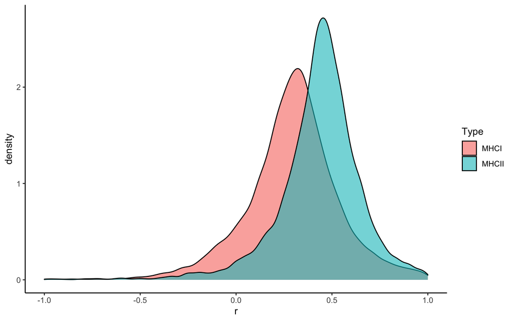

```r
result <- rbind(MHCI,MHCII)
ggplot(result,aes(r,fill = Type)) +
  geom_density(alpha = 0.6) + theme_bw() + theme(axis.line = element_line(colour = "black"),
                                             panel.grid.major = element_blank(),
                                             panel.grid.minor = element_blank(),
                                             panel.border = element_blank(),
                                             panel.background = element_blank())
```

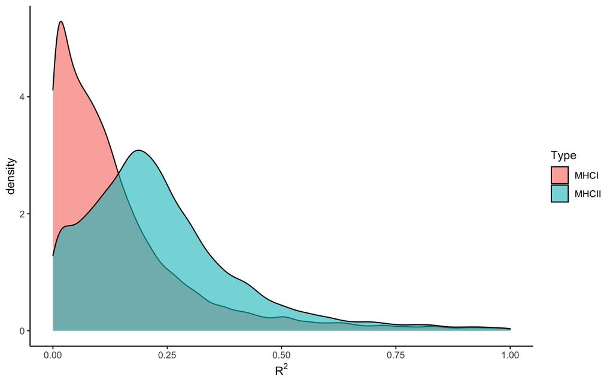

```r
ggsave("../figure/BA_IMM_r.pdf",dpi = 300,width = 6,height = 6)
ggplot(result,aes(r2,fill = Type)) +
  geom_density(alpha = 0.6) + theme_bw()+ theme(axis.line = element_line(colour = "black"),
                                 panel.grid.major = element_blank(),
                                 panel.grid.minor = element_blank(),
                                 panel.border = element_blank(),
                                 panel.background = element_blank())+xlab(bquote(R^2))
```

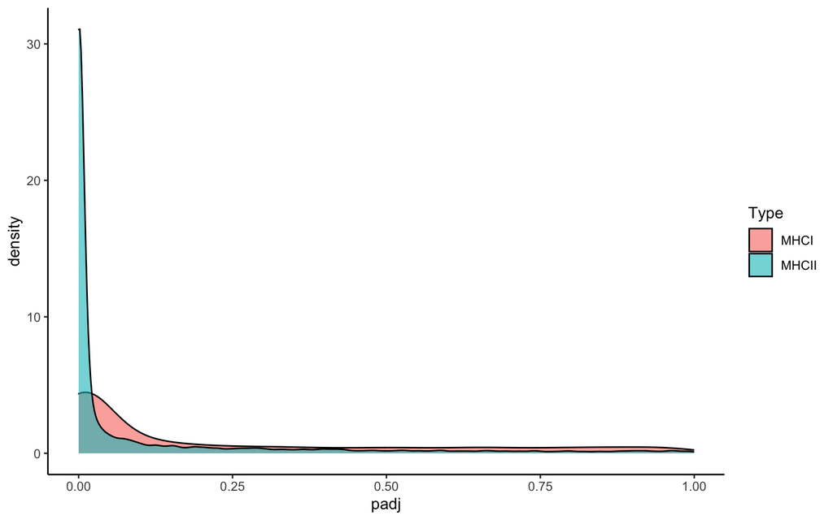

```r
ggsave("../figure/BA_IMM_r2.pdf",dpi = 300,width = 6,height = 6)
ggplot(result,aes(padj,fill = Type)) +
  geom_density(alpha = 0.6) + theme_bw()+ theme(axis.line = element_line(colour = "black"),
                                                panel.grid.major = element_blank(),
                                                panel.grid.minor = element_blank(),
                                                panel.border = element_blank(),
                                                panel.background = element_blank())
```

```r
ggsave("../figure/BA_IMM_padj.pdf",dpi = 300,width = 6,height = 6)
```

The correlations were positive, significant but low in magnitude, median Pearson r2 = 0.0968 in the compare between MHC I binding affinity rank and MHC II immunogenicity rank; and median Pearson r2 = 0.2057 in the compare between MHC II binding affinity rank and MHC II immunogenicity rank . Overall, this analysis suggested that the TLimmuno2 is at least partially non-redundant with the binding affinity predictor.

### immunoediting signal detect

We analyzed all neoepitopes in TCGA using TLimmuno2 and set cutoff to 2% to obtain neoantigens.

```python
#PBS_batch
#python
import os
import pandas as pd
import re
file_path3 = "/public/slst/home/wanggsh/TCGA-process/Prediction/IMM_rank2"
def get_neoantigen(Data):
    DF = pd.DataFrame()
    for i in Data["Sample_Barcode"].unique():
        Data_sample = Data[Data["Sample_Barcode"] == i]
        for x in  Data_sample["chr"].unique():
            Data_chr = Data_sample[Data_sample["chr"] == x]
            for start in Data_chr["start"].unique():
                Data_str = Data_chr[Data_chr["start"] == start]
                prediction = []
                for y in Data_str["hla"].unique():
                    Data_hla = Data_str[Data_str["hla"] == y]
                    pre = Data_hla["Rank"].min()
                    prediction.append(pre)
                Data_str["Result"] = min(prediction)
                Data_final = Data_str[["tumor_sample_barcode","Sample_Barcode","chr","start","end","ref","alt","Result"]]
                Data_final = Data_final.drop_duplicates()
                DF = pd.concat([DF,Data_final])
    DF["label"] = DF["Result"].map(lambda x : 1 if x <0.02 else 0)
    return DF
file = os.listdir(file_path3)
for i in file:
    tumor = re.split(".csv_rank.csv",i)[0]
    Data = pd.read_csv("{}/{}".format(file_path3,i))
    result = get_neoantigen(Data)
    result.to_csv("".format(tumor))
```

Then we can calculate and compare the median actual CCF-ES with median simulation CCF-ES in pan-cancer and cancer-type:

```r
#R
ccf <- readRDS("all_mut_mis_ccf.rds")
files <- list.files("~/Project/MHCII/Data/TCGA/neoantigen_es/",full.names = TRUE)
res <- lapply(files,
              function(x){
                read.csv(x) %>% select(-X)
              })
mut_all <- bind_rows(res)
saveRDS(mut_all,file = "mut_all.rds")

mut_all <- mut_all %>%
  mutate(index=paste(substr(tumor_sample_barcode,1,16),
                     chr,start,ref,alt,sep = ":")) %>%
  select(index,Result,label)
all_mut_ccf <- inner_join(
  mut_all,
  ccf %>% select(-sample),
  by="index"
)
all_mut_ccf <- all_mut_ccf[!duplicated(all_mut_ccf$index),]
all_mut_ccf$sample <- substr(all_mut_ccf$index,1,16)
all_mut_ccf <- all_mut_ccf %>% rename(gene = Hugo_Symbol)
TPM_log2 <- data.table::fread("tcga_RSEM_gene_tpm.gz")  #too large,not include
mapping <- data.table::fread("mapping_probe")
mapping <- mapping[,1:2]
TPM_log2_mapping <- left_join(TPM_log2 %>% rename(id=sample),mapping) %>%
  select(id,gene,everything())###log2(tpm+0.001)
TPM_log2_mapping <- as.data.frame(TPM_log2_mapping)
tpm_trans <- TPM_log2_mapping
tpm_trans[,3:ncol(tpm_trans)] <- apply(TPM_log2_mapping[,3:ncol(TPM_log2_mapping)],2,
                                       function(x){(2^x) - 0.001})
saveRDS(tpm_trans,file = "tpm_trans.rds")
tpm <- readRDS("tpm_trans.rds")
tpm <- tpm[!duplicated(tpm$gene),]

all_mut_ccf$tpm_exp <- mapply(function(sample,gene){
  tpm[tpm$gene==gene,substr(sample,1,15)]
},all_mut_ccf$sample,all_mut_ccf$gene)

all_mut_ccf_tpm <- all_mut_ccf %>%
  filter(lengths(tpm_exp)!=0)

all_mut_ccf_tpm$tpm_exp <- as.numeric(all_mut_ccf_tpm$tpm_exp)

all_mut_ccf_tpm <- all_mut_ccf_tpm %>%
  mutate(neo=ifelse(label==1 & tpm_exp>1,"neo","not_neo"))   #neo antigen& log expression >1

saveRDS(all_mut_ccf_tpm,file = "mut_ccf_tpm_neo.rds")
```

```r
cal_nes_warp <- function(dt){
  results_ccf <- vector("list",length = length(unique(dt$sample)))
  names(results_ccf) <- unique(dt$sample)

  cl <- makeCluster(getOption("cl.cores", 15),type="FORK")
  results_ccf <- parSapply(cl=cl,names(results_ccf),
                           function(x){
                             data <- dt %>% filter(sample == x)
                             a <- NeoEnrichment::cal_nes_new_test(dt = data,
                                                                  sample_counts = 1000,
                                                                  need_p = FALSE)
                             return(a)
                           },simplify = FALSE)
  stopCluster(cl)
  results_ccf <- Filter(function(x){length(x)>1},results_ccf)
  pancancer_nes_ccf <- bind_rows(results_ccf)
  return(pancancer_nes_ccf)
}  #ES score

all_mut_ccf <- readRDS("../data/mut_ccf_tpm_neo.rds")
all_mut_ccf <- all_mut_ccf %>%
  rename(ccf=ccf_hat) %>%
  mutate(neo=ifelse(neo=="neo","yes","no"))

samples_has_subclonal <- all_mut_ccf %>%
  filter(ccf<0.6) %>%
  select(sample) %>%
  distinct(sample)

all_mut_ccf  %>%
  filter(sample %in% samples_has_subclonal$sample) %>%
  group_by(sample) %>%
  summarise(c_n=sum(neo=="yes"),c_m=sum(neo=="no")) %>% filter(c_n>=1 & c_m >=1) -> summ

driver_mutations <- readRDS("../data/driver_mutations.rds")
#reduce driver mutation
all_mut_ccf <- all_mut_ccf %>%
  mutate(gene_protein_change=paste(gene,Protein_Change,sep = "-"))
driver_mutations <- driver_mutations %>%
  mutate(gene_protein_change=paste(gene,protein_change,sep = "-"))

all_mut_ccf <- all_mut_ccf %>%
  mutate(is_driver=ifelse(gene_protein_change %in% driver_mutations$gene_protein_change,"yes","no"))

sum(all_mut_ccf$is_driver=="yes" & all_mut_ccf$neo=="yes") / sum(all_mut_ccf$neo=="yes")##0.01618271

all_mut_ccf %>% group_by(sample) %>%
  summarise(inter_gene=intersect(gene[neo=="yes"],
                                 gene[is_driver=="yes"])) -> aaa##701 samples
all_mut_ccf <- all_mut_ccf %>%
  mutate(sample_neo_index=paste(sample,neo,gene,sep = ","))
aaa <- aaa %>% mutate(sample_neo_index=paste(sample,"yes",inter_gene,sep = ","))

all_mut_ccf %>%
  mutate(in_aaa = ifelse(sample_neo_index %in% aaa$sample_neo_index,"yes","no")) %>%
  group_by(sample) %>%
  summarise(need_sample=ifelse(any(in_aaa=="yes"),"no","yes")) %>%
  filter(need_sample=="yes") -> summ2
need_samples <- intersect(samples_has_subclonal$sample,summ2$sample)
all_mut_ccf %>% filter(!is.na(ccf)) %>%
  filter(sample %in% need_samples) %>%
  group_by(sample) %>%
  summarise(c_n=sum(neo=="yes"),c_m=sum(neo=="no")) %>% filter(c_n>=1 & c_m >=1) -> summ
neo_missense <- all_mut_ccf %>% filter(sample %in% summ$sample)
neo_missense <- neo_missense %>% select(sample,neo,ccf) %>% filter(!is.na(ccf))

library(parallel)
neo_nes <- cal_nes_warp(neo_missense)
saveRDS(neo_nes,file = "../data/neo_es.rds")
```

```r
#R
neo_nes <- readRDS("../data/neo_es.rds")
all_mut_ccf <- readRDS("mut_ccf_tpm_neo.rds")
all_mut_ccf <- all_mut_ccf %>%
  rename(ccf=ccf_hat) %>%
  mutate(neo=ifelse(neo=="neo","yes","no"))
neo_missense <- all_mut_ccf %>%
  filter(sample %in% neo_nes$sample)
neo_missense <- neo_missense %>%
  select(sample,neo,ccf) %>%
  filter(!is.na(ccf))

cal_nes_warp <- function(dt){
  results_ccf <- vector("list",length = length(unique(dt$sample)))
  names(results_ccf) <- unique(dt$sample)

  cl <- makeCluster(getOption("cl.cores", 15),type="FORK")
  results_ccf <- parSapply(cl=cl,names(results_ccf),
                           function(x){
                             data <- dt %>% filter(sample == x)
                             a <- NeoEnrichment::cal_nes_new_test(dt = data,
                                                                  sample_counts = 1000,
                                                                  need_p = FALSE)
                             return(a)
                           },simplify = FALSE)
  stopCluster(cl)
  results_ccf <- Filter(function(x){length(x)>1},results_ccf)
  pancancer_nes_ccf <- bind_rows(results_ccf)
  return(pancancer_nes_ccf)
}
res <- vector("list",2000)
for (i in 1:2000){
  neo_missense_sim <- neo_missense %>%
    group_by(sample) %>%
    mutate(neo_sim=sample(neo,length(neo))) %>%
    ungroup()
  neo_missense_sim <- neo_missense_sim %>%
    select(-neo) %>%
    rename(neo=neo_sim)
  neo_nes_sim <- cal_nes_warp(neo_missense_sim)
  neo_nes_sim$sim_num <- i
  res[[i]] <- neo_nes_sim
  print(paste0("Complete ",i," sim. "))
}
saveRDS(res,file = "sim_2000_not_filter_driver.rds")

neo_nes <- readRDS("neo_es.rds")
sim_all <- readRDS("sim_2000_not_filter_driver.rds")
sim_all <- bind_rows(sim_all)
sim_all$cancer <- get_cancer_type(sim_all$sample,parallel = TRUE,cores = 20)
saveRDS(sim_all,file = "sim_add_cancer.rds")
```

```r
#R
neo_nes <- readRDS("../data/neo_es.rds")
sim_all <- readRDS("../data/sim_add_cancer.rds")
sim_all %>%
  group_by(cancer,sim_num) %>%
  summarise(median_es=median(es)) -> summ2
```

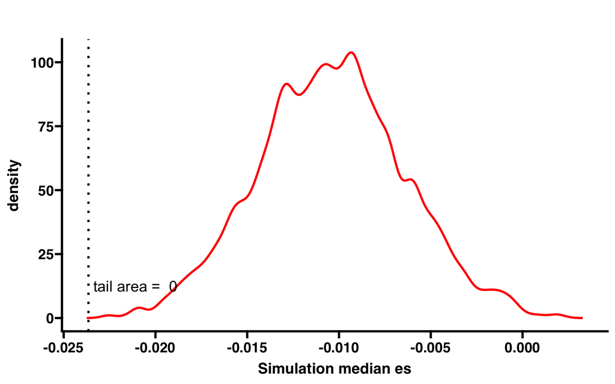

```r
neo_nes$cancer <- get_cancer_type(neo_nes$sample)
neo_nes_summ <- neo_nes %>%
  group_by(cancer) %>% summarise(median_es=median(es))
sim_all %>%
  group_by(sim_num) %>%
  summarise(median_es=median(es)) -> summ
p <- WVPlots::ShadedDensity(frame = summ,
                            xvar = "median_es",
                            threshold = median(neo_nes$es),
                            title = "",
                            tail = "left")

p$layers[[1]]$aes_params$colour <- "red"
p$layers[[1]]$aes_params$size <- 1
p$layers[[2]]$aes_params$fill <- "blue"     #geom_ribbon
p$layers[[3]]$aes_params$colour <- "black"
p$layers[[3]]$aes_params$size <- 1
#p$layers[[4]]$aes_params$label <- "Actual median ES" #geom_text
p1 <- p + labs(x="Simulation median es")+
  theme_prism()
p1
```

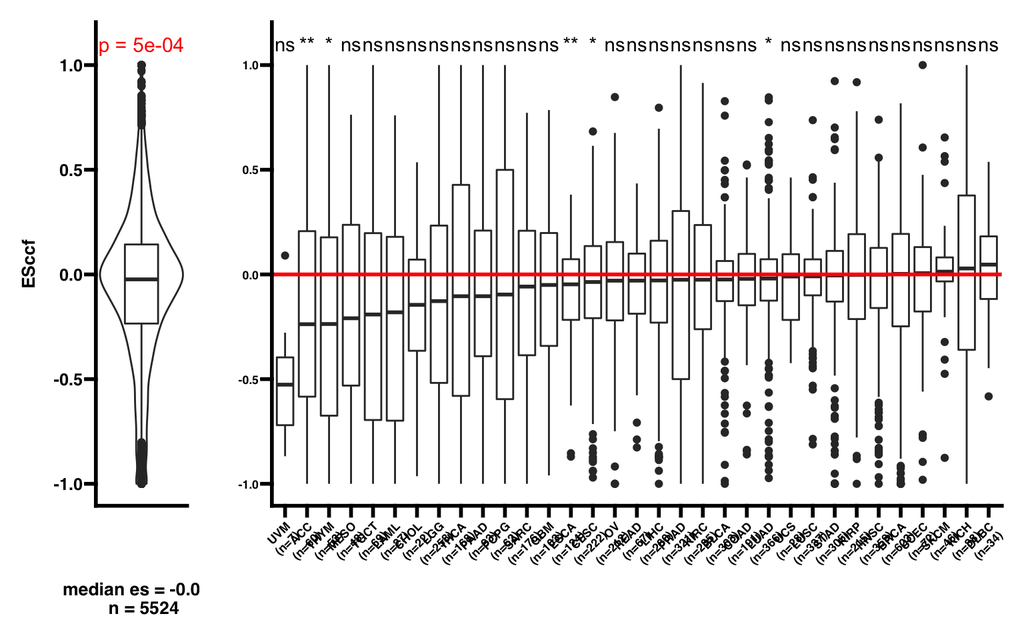

```r
ggsave("../figure/null_dis.pdf")
##cancer type
neo_nes_summ <- neo_nes_summ %>%
  rowwise() %>%
  mutate(p=mean(summ2$median_es[summ2$cancer==cancer] <= median_es))
get_f1 <- function(dt,pancancer_p,dt2,median_es){
  p1 <- ggplot(data=dt,aes(x=1,y=es))+
    geom_violin(alpha=0.7,width=0.5)+
    geom_boxplot(width=0.2)+
    theme_prism()+
    labs(x=paste0("median es = ",round(median_es,digits = 3),"\n n = ",nrow(dt)),y = "ESccf",size=5)+
    theme(axis.ticks.x = element_blank(),
          axis.text.x = element_blank())+
    theme(text = element_text(size = 10))+
    annotate(geom="text", x=1, y=1.1, label=paste0("p = ",pancancer_p),
             color="red",size=4)
  dt$cancer <- get_cancer_type(dt$sample)
  dt %>% group_by(cancer) %>%
    summarise(median_est=median(es),c=n()) %>%
    arrange(median_est) %>%
    mutate(label=paste0(cancer,"\n(n=",c,")"))-> summ1
  summ1 <- left_join(summ1,dt2 %>% select(cancer,p))
  summ1$p <- signif(summ1$p,digits = 1)
  summ1 <- summ1 %>%
    mutate(sig=case_when(
      p <= 0.05 & p > 0.01 ~ "*",
      p < 0.01 ~ "**",
      TRUE ~ "ns"
    ))
  dt <- left_join(dt,summ1)
  dt$label <- factor(dt$label,levels = summ1$label)
  df2 <- data.frame(x = 1:nrow(summ1), y = 1.1, family = summ1$sig)
  p2 <- ggplot(data=dt,aes(x=label,y=es))+
    geom_boxplot()+
    theme_prism()+
    theme(axis.title.x = element_blank())+
    theme(axis.text.x = element_text(angle = 45,vjust = 1, hjust = 1))+
    theme(text = element_text(size = 7))+
    geom_text(data=df2,aes(x=x,y=y,label = family))+
    geom_hline(yintercept=0,
               color = "red", size=1)+labs(y = "")
  p3 <- p1 + p2 + plot_layout(widths = c(1, 8))
}

p2 <- get_f1(neo_nes,pancancer_p = 0.0005,
             dt2 = neo_nes_summ,median_es = median(neo_nes$es))
p2
```

```r
ggsave("../figure/immuno_edit.pdf",width = 12,height = 5,dpi = 300)
```

```r
sim_all <- readRDS("../data/net_sim_add_cancer.rds")
neo_nes <- readRDS("../data/net_neo_es.rds")
sim_all %>%
  group_by(cancer,sim_num) %>%
  summarise(median_es=median(es)) -> summ2
```

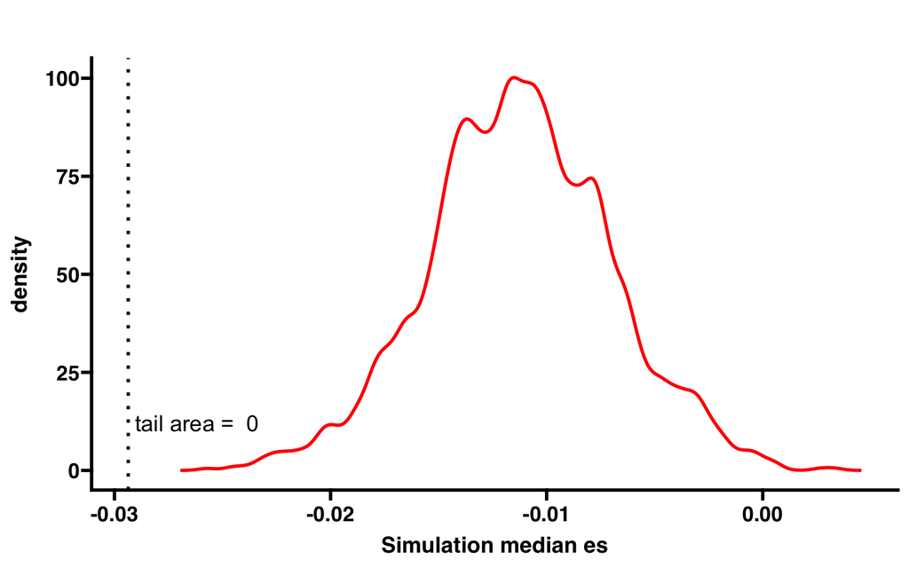

```r
neo_nes$cancer <- get_cancer_type(neo_nes$sample)
neo_nes_summ <- neo_nes %>%
  group_by(cancer) %>% summarise(median_es=median(es))
sim_all %>%
  group_by(sim_num) %>%
  summarise(median_es=median(es)) -> summ
p <- WVPlots::ShadedDensity(frame = summ,
                            xvar = "median_es",
                            threshold = median(neo_nes$es),
                            title = "",
                            tail = "left")

p$layers[[1]]$aes_params$colour <- "red"
p$layers[[1]]$aes_params$size <- 1
p$layers[[2]]$aes_params$fill <- "blue"     #geom_ribbon
p$layers[[3]]$aes_params$colour <- "black"
p$layers[[3]]$aes_params$size <- 1
#p$layers[[4]]$aes_params$label <- "Actual median ES" #geom_text
p1 <- p + labs(x="Simulation median es")+
  theme_prism()
p1
```

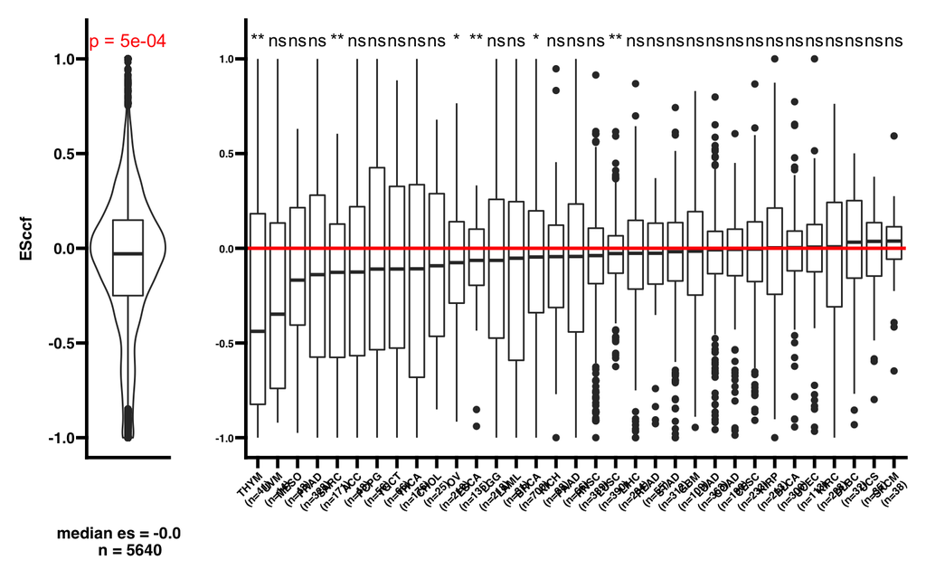

```r
ggsave("../figure/net_null_dis.pdf")
##cancer type
neo_nes_summ <- neo_nes_summ %>%
  rowwise() %>%
  mutate(p=mean(summ2$median_es[summ2$cancer==cancer] <= median_es))
get_f1 <- function(dt,pancancer_p,dt2,median_es){
  p1 <- ggplot(data=dt,aes(x=1,y=es))+
    geom_violin(alpha=0.7,width=0.5)+
    geom_boxplot(width=0.2)+
    theme_prism()+
    labs(x=paste0("median es = ",round(median_es,digits = 3),"\n n = ",nrow(dt)),size=7)+
    theme(axis.ticks.x = element_blank(),
          axis.text.x = element_blank())+
    theme(text = element_text(size = 10))+
    annotate(geom="text", x=1, y=1.1, label=paste0("p = ",pancancer_p),
             color="red",size=4)+labs(y = "ESccf",size = 8)
  dt$cancer <- get_cancer_type(dt$sample)
  dt %>% group_by(cancer) %>%
    summarise(median_est=median(es),c=n()) %>%
    arrange(median_est) %>%
    mutate(label=paste0(cancer,"\n(n=",c,")"))-> summ1
  summ1 <- left_join(summ1,dt2 %>% select(cancer,p))
  summ1$p <- signif(summ1$p,digits = 1)
  summ1 <- summ1 %>%
    mutate(sig=case_when(
      p <= 0.05 & p > 0.01 ~ "*",
      p < 0.01 ~ "**",
      TRUE ~ "ns"
    ))
  dt <- left_join(dt,summ1)
  dt$label <- factor(dt$label,levels = summ1$label)
  df2 <- data.frame(x = 1:nrow(summ1), y = 1.1, family = summ1$sig)
  p2 <- ggplot(data=dt,aes(x=label,y=es))+
    geom_boxplot()+
    theme_prism()+
    theme(axis.title.x = element_blank())+
    theme(axis.text.x = element_text(angle = 45,vjust = 1, hjust = 1))+
    theme(text = element_text(size = 7))+
    geom_text(data=df2,aes(x=x,y=y,label = family))+
    geom_hline(yintercept=0,
               color = "red", size=1)+labs(y = "")
  p3 <- p1 + p2 + plot_layout(widths = c(1, 8))

}

p2 <- get_f1(neo_nes,pancancer_p = 0.0005,
             dt2 = neo_nes_summ,median_es = median(neo_nes$es))
p2
```

```r
ggsave("../figure/net_immunoediting.pdf",width = 12,height = 5,dpi = 300)
```